# The Beautiful Game. Investigating European Football Database

- Introduction
- Data Wrangling
- Exploratory Data Analysis
- Conclusions

## Introduction

This football dataset is obtained from Kaggle. The data contains more than 25,000 matches, +10,000 players, 11 European countries, team squad formation with (X, Y) coordinates, detailed match events; for example, goal types, possessions, fouls, cards and many more. The dataset spans from 2008 to 2016 seasons and it comes in SQLite database format with 7 tables (Country, League, Match, Player, Player_Attributes, Team, and Team_Attributes). In addition, there are 199 columns combined in this database. We will extract what serves our purpose of analysis and try answer some questions; for instance, **which teams had scored the most number of goals? what team improved over the period of time? who scored the most penalties?** and also dig in to explore players distinctions that dominates the game.

All thanks to [Hugo Mathien](https://www.kaggle.com/hugomathien) for dedicating the time and effort to make this possbile. Further reading and ways to improve the project can be found in Hugo's github repo [here.](https://github.com/hugomathien/football-data-collection)

```python
import pandas as pd
import numpy as np
import matplotlib.pyplot as plt
import matplotlib.cm as cm
from math import log10
import seaborn as sns
from sqlite3 import connect
import os
%matplotlib inline
```

## Data Wrangling

### Database connection

```python
# database connection
db = os.getcwd()+'/database.sqlite'
conn = connect(db)



# perform joins

# team_df = pd.read_sql_query("""SELECT *
#                   FROM Team as t
#                   JOIN Team_Attributes as ta ON t.team_api_id=ta.team_api_id""", conn)

# player_df = pd.read_sql_query("""SELECT *
#                   FROM Player as p
#                   JOIN Player_Attributes as pa ON p.player_api_id=pa.player_api_id""", conn)
```

### Explore database tables

```python
# explore database

db_tables = pd.read_sql("SELECT * FROM sqlite_master WHERE type='table';", conn)
db_tables
```

|  | type | name | tbl_name | rootpage | sql |
| --- | --- | --- | --- | --- | --- |
| 0 | table | sqlite_sequence | sqlite_sequence | 4 | CREATE TABLE sqlite_sequence(name,seq) |
| 1 | table | Player_Attributes | Player_Attributes | 11 | CREATE TABLE "Player_Attributes" (\n\t`id`\tIN... |
| 2 | table | Player | Player | 14 | CREATE TABLE `Player` (\n\t`id`\tINTEGER PRIMA... |
| 3 | table | Match | Match | 18 | CREATE TABLE `Match` (\n\t`id`\tINTEGER PRIMAR... |
| 4 | table | League | League | 24 | CREATE TABLE `League` (\n\t`id`\tINTEGER PRIMA... |
| 5 | table | Country | Country | 26 | CREATE TABLE `Country` (\n\t`id`\tINTEGER PRIM... |
| 6 | table | Team | Team | 29 | CREATE TABLE "Team" (\n\t`id`\tINTEGER PRIMARY... |
| 7 | table | Team_Attributes | Team_Attributes | 2 | CREATE TABLE `Team_Attributes` (\n\t`id`\tINTE... |

### Explore tables

```python
# Team table
pd.read_sql_query("SELECT * FROM Team", conn)
```

|  | id | team_api_id | team_fifa_api_id | team_long_name | team_short_name |
| --- | --- | --- | --- | --- | --- |
| 0 | 1 | 9987 | 673.0 | KRC Genk | GEN |
| 1 | 2 | 9993 | 675.0 | Beerschot AC | BAC |
| 2 | 3 | 10000 | 15005.0 | SV Zulte-Waregem | ZUL |
| 3 | 4 | 9994 | 2007.0 | Sporting Lokeren | LOK |
| 4 | 5 | 9984 | 1750.0 | KSV Cercle Brugge | CEB |
| ... | ... | ... | ... | ... | ... |
| 294 | 49479 | 10190 | 898.0 | FC St. Gallen | GAL |
| 295 | 49837 | 10191 | 1715.0 | FC Thun | THU |
| 296 | 50201 | 9777 | 324.0 | Servette FC | SER |
| 297 | 50204 | 7730 | 1862.0 | FC Lausanne-Sports | LAU |
| 298 | 51606 | 7896 | NaN | Lugano | LUG |

299 rows × 5 columns

```python
# Team attributes table
pd.read_sql_query("SELECT * FROM Team_Attributes", conn)
```

|  | id | team_fifa_api_id | team_api_id | date | buildUpPlaySpeed | buildUpPlaySpeedClass | buildUpPlayDribbling | buildUpPlayDribblingClass | buildUpPlayPassing | buildUpPlayPassingClass | ... | chanceCreationShooting | chanceCreationShootingClass | chanceCreationPositioningClass | defencePressure | defencePressureClass | defenceAggression | defenceAggressionClass | defenceTeamWidth | defenceTeamWidthClass | defenceDefenderLineClass |
| --- | --- | --- | --- | --- | --- | --- | --- | --- | --- | --- | --- | --- | --- | --- | --- | --- | --- | --- | --- | --- | --- |
| 0 | 1 | 434 | 9930 | 2010-02-22 00:00:00 | 60 | Balanced | NaN | Little | 50 | Mixed | ... | 55 | Normal | Organised | 50 | Medium | 55 | Press | 45 | Normal | Cover |
| 1 | 2 | 434 | 9930 | 2014-09-19 00:00:00 | 52 | Balanced | 48.0 | Normal | 56 | Mixed | ... | 64 | Normal | Organised | 47 | Medium | 44 | Press | 54 | Normal | Cover |
| 2 | 3 | 434 | 9930 | 2015-09-10 00:00:00 | 47 | Balanced | 41.0 | Normal | 54 | Mixed | ... | 64 | Normal | Organised | 47 | Medium | 44 | Press | 54 | Normal | Cover |
| 3 | 4 | 77 | 8485 | 2010-02-22 00:00:00 | 70 | Fast | NaN | Little | 70 | Long | ... | 70 | Lots | Organised | 60 | Medium | 70 | Double | 70 | Wide | Cover |
| 4 | 5 | 77 | 8485 | 2011-02-22 00:00:00 | 47 | Balanced | NaN | Little | 52 | Mixed | ... | 52 | Normal | Organised | 47 | Medium | 47 | Press | 52 | Normal | Cover |
| ... | ... | ... | ... | ... | ... | ... | ... | ... | ... | ... | ... | ... | ... | ... | ... | ... | ... | ... | ... | ... | ... |
| 1453 | 1454 | 15005 | 10000 | 2011-02-22 00:00:00 | 52 | Balanced | NaN | Little | 52 | Mixed | ... | 53 | Normal | Organised | 46 | Medium | 48 | Press | 53 | Normal | Cover |
| 1454 | 1455 | 15005 | 10000 | 2012-02-22 00:00:00 | 54 | Balanced | NaN | Little | 51 | Mixed | ... | 50 | Normal | Organised | 44 | Medium | 55 | Press | 53 | Normal | Cover |
| 1455 | 1456 | 15005 | 10000 | 2013-09-20 00:00:00 | 54 | Balanced | NaN | Little | 51 | Mixed | ... | 32 | Little | Organised | 44 | Medium | 58 | Press | 37 | Normal | Cover |
| 1456 | 1457 | 15005 | 10000 | 2014-09-19 00:00:00 | 54 | Balanced | 42.0 | Normal | 51 | Mixed | ... | 32 | Little | Organised | 44 | Medium | 58 | Press | 37 | Normal | Cover |
| 1457 | 1458 | 15005 | 10000 | 2015-09-10 00:00:00 | 54 | Balanced | 42.0 | Normal | 51 | Mixed | ... | 32 | Little | Organised | 44 | Medium | 58 | Press | 37 | Normal | Cover |

1458 rows × 25 columns

```python
# Player table
pd.read_sql_query("SELECT * FROM Player", conn)
```

|  | id | player_api_id | player_name | player_fifa_api_id | birthday | height | weight |
| --- | --- | --- | --- | --- | --- | --- | --- |
| 0 | 1 | 505942 | Aaron Appindangoye | 218353 | 1992-02-29 00:00:00 | 182.88 | 187 |
| 1 | 2 | 155782 | Aaron Cresswell | 189615 | 1989-12-15 00:00:00 | 170.18 | 146 |
| 2 | 3 | 162549 | Aaron Doran | 186170 | 1991-05-13 00:00:00 | 170.18 | 163 |
| 3 | 4 | 30572 | Aaron Galindo | 140161 | 1982-05-08 00:00:00 | 182.88 | 198 |
| 4 | 5 | 23780 | Aaron Hughes | 17725 | 1979-11-08 00:00:00 | 182.88 | 154 |
| ... | ... | ... | ... | ... | ... | ... | ... |
| 11055 | 11071 | 26357 | Zoumana Camara | 2488 | 1979-04-03 00:00:00 | 182.88 | 168 |
| 11056 | 11072 | 111182 | Zsolt Laczko | 164680 | 1986-12-18 00:00:00 | 182.88 | 176 |
| 11057 | 11073 | 36491 | Zsolt Low | 111191 | 1979-04-29 00:00:00 | 180.34 | 154 |
| 11058 | 11074 | 35506 | Zurab Khizanishvili | 47058 | 1981-10-06 00:00:00 | 185.42 | 172 |
| 11059 | 11075 | 39902 | Zvjezdan Misimovic | 102359 | 1982-06-05 00:00:00 | 180.34 | 176 |

11060 rows × 7 columns

```python
# Player attributes table
pd.read_sql_query("SELECT * FROM Player_Attributes", conn)
```

|  | id | player_fifa_api_id | player_api_id | date | overall_rating | potential | preferred_foot | attacking_work_rate | defensive_work_rate | crossing | ... | vision | penalties | marking | standing_tackle | sliding_tackle | gk_diving | gk_handling | gk_kicking | gk_positioning | gk_reflexes |
| --- | --- | --- | --- | --- | --- | --- | --- | --- | --- | --- | --- | --- | --- | --- | --- | --- | --- | --- | --- | --- | --- |
| 0 | 1 | 218353 | 505942 | 2016-02-18 00:00:00 | 67.0 | 71.0 | right | medium | medium | 49.0 | ... | 54.0 | 48.0 | 65.0 | 69.0 | 69.0 | 6.0 | 11.0 | 10.0 | 8.0 | 8.0 |
| 1 | 2 | 218353 | 505942 | 2015-11-19 00:00:00 | 67.0 | 71.0 | right | medium | medium | 49.0 | ... | 54.0 | 48.0 | 65.0 | 69.0 | 69.0 | 6.0 | 11.0 | 10.0 | 8.0 | 8.0 |
| 2 | 3 | 218353 | 505942 | 2015-09-21 00:00:00 | 62.0 | 66.0 | right | medium | medium | 49.0 | ... | 54.0 | 48.0 | 65.0 | 66.0 | 69.0 | 6.0 | 11.0 | 10.0 | 8.0 | 8.0 |
| 3 | 4 | 218353 | 505942 | 2015-03-20 00:00:00 | 61.0 | 65.0 | right | medium | medium | 48.0 | ... | 53.0 | 47.0 | 62.0 | 63.0 | 66.0 | 5.0 | 10.0 | 9.0 | 7.0 | 7.0 |
| 4 | 5 | 218353 | 505942 | 2007-02-22 00:00:00 | 61.0 | 65.0 | right | medium | medium | 48.0 | ... | 53.0 | 47.0 | 62.0 | 63.0 | 66.0 | 5.0 | 10.0 | 9.0 | 7.0 | 7.0 |
| ... | ... | ... | ... | ... | ... | ... | ... | ... | ... | ... | ... | ... | ... | ... | ... | ... | ... | ... | ... | ... | ... |
| 183973 | 183974 | 102359 | 39902 | 2009-08-30 00:00:00 | 83.0 | 85.0 | right | medium | low | 84.0 | ... | 88.0 | 83.0 | 22.0 | 31.0 | 30.0 | 9.0 | 20.0 | 84.0 | 20.0 | 20.0 |
| 183974 | 183975 | 102359 | 39902 | 2009-02-22 00:00:00 | 78.0 | 80.0 | right | medium | low | 74.0 | ... | 88.0 | 70.0 | 32.0 | 31.0 | 30.0 | 9.0 | 20.0 | 73.0 | 20.0 | 20.0 |
| 183975 | 183976 | 102359 | 39902 | 2008-08-30 00:00:00 | 77.0 | 80.0 | right | medium | low | 74.0 | ... | 88.0 | 70.0 | 32.0 | 31.0 | 30.0 | 9.0 | 20.0 | 73.0 | 20.0 | 20.0 |
| 183976 | 183977 | 102359 | 39902 | 2007-08-30 00:00:00 | 78.0 | 81.0 | right | medium | low | 74.0 | ... | 88.0 | 53.0 | 28.0 | 32.0 | 30.0 | 9.0 | 20.0 | 73.0 | 20.0 | 20.0 |
| 183977 | 183978 | 102359 | 39902 | 2007-02-22 00:00:00 | 80.0 | 81.0 | right | medium | low | 74.0 | ... | 88.0 | 53.0 | 38.0 | 32.0 | 30.0 | 9.0 | 9.0 | 78.0 | 7.0 | 15.0 |

183978 rows × 42 columns

```python
# Match table
pd.read_sql_query("SELECT * FROM Match", conn)
```

|  | id | country_id | league_id | season | stage | date | match_api_id | home_team_api_id | away_team_api_id | home_team_goal | ... | SJA | VCH | VCD | VCA | GBH | GBD | GBA | BSH | BSD | BSA |
| --- | --- | --- | --- | --- | --- | --- | --- | --- | --- | --- | --- | --- | --- | --- | --- | --- | --- | --- | --- | --- | --- |
| 0 | 1 | 1 | 1 | 2008/2009 | 1 | 2008-08-17 00:00:00 | 492473 | 9987 | 9993 | 1 | ... | 4.00 | 1.65 | 3.40 | 4.50 | 1.78 | 3.25 | 4.00 | 1.73 | 3.40 | 4.20 |
| 1 | 2 | 1 | 1 | 2008/2009 | 1 | 2008-08-16 00:00:00 | 492474 | 10000 | 9994 | 0 | ... | 3.80 | 2.00 | 3.25 | 3.25 | 1.85 | 3.25 | 3.75 | 1.91 | 3.25 | 3.60 |
| 2 | 3 | 1 | 1 | 2008/2009 | 1 | 2008-08-16 00:00:00 | 492475 | 9984 | 8635 | 0 | ... | 2.50 | 2.35 | 3.25 | 2.65 | 2.50 | 3.20 | 2.50 | 2.30 | 3.20 | 2.75 |
| 3 | 4 | 1 | 1 | 2008/2009 | 1 | 2008-08-17 00:00:00 | 492476 | 9991 | 9998 | 5 | ... | 7.50 | 1.45 | 3.75 | 6.50 | 1.50 | 3.75 | 5.50 | 1.44 | 3.75 | 6.50 |
| 4 | 5 | 1 | 1 | 2008/2009 | 1 | 2008-08-16 00:00:00 | 492477 | 7947 | 9985 | 1 | ... | 1.73 | 4.50 | 3.40 | 1.65 | 4.50 | 3.50 | 1.65 | 4.75 | 3.30 | 1.67 |
| ... | ... | ... | ... | ... | ... | ... | ... | ... | ... | ... | ... | ... | ... | ... | ... | ... | ... | ... | ... | ... | ... |
| 25974 | 25975 | 24558 | 24558 | 2015/2016 | 9 | 2015-09-22 00:00:00 | 1992091 | 10190 | 10191 | 1 | ... | NaN | NaN | NaN | NaN | NaN | NaN | NaN | NaN | NaN | NaN |
| 25975 | 25976 | 24558 | 24558 | 2015/2016 | 9 | 2015-09-23 00:00:00 | 1992092 | 9824 | 10199 | 1 | ... | NaN | NaN | NaN | NaN | NaN | NaN | NaN | NaN | NaN | NaN |
| 25976 | 25977 | 24558 | 24558 | 2015/2016 | 9 | 2015-09-23 00:00:00 | 1992093 | 9956 | 10179 | 2 | ... | NaN | NaN | NaN | NaN | NaN | NaN | NaN | NaN | NaN | NaN |
| 25977 | 25978 | 24558 | 24558 | 2015/2016 | 9 | 2015-09-22 00:00:00 | 1992094 | 7896 | 10243 | 0 | ... | NaN | NaN | NaN | NaN | NaN | NaN | NaN | NaN | NaN | NaN |
| 25978 | 25979 | 24558 | 24558 | 2015/2016 | 9 | 2015-09-23 00:00:00 | 1992095 | 10192 | 9931 | 4 | ... | NaN | NaN | NaN | NaN | NaN | NaN | NaN | NaN | NaN | NaN |

25979 rows × 115 columns

```python
# League table
pd.read_sql_query("SELECT * FROM League", conn)
```

|  | id | country_id | name |
| --- | --- | --- | --- |
| 0 | 1 | 1 | Belgium Jupiler League |
| 1 | 1729 | 1729 | England Premier League |
| 2 | 4769 | 4769 | France Ligue 1 |
| 3 | 7809 | 7809 | Germany 1. Bundesliga |
| 4 | 10257 | 10257 | Italy Serie A |
| 5 | 13274 | 13274 | Netherlands Eredivisie |
| 6 | 15722 | 15722 | Poland Ekstraklasa |
| 7 | 17642 | 17642 | Portugal Liga ZON Sagres |
| 8 | 19694 | 19694 | Scotland Premier League |
| 9 | 21518 | 21518 | Spain LIGA BBVA |
| 10 | 24558 | 24558 | Switzerland Super League |

```python
# Country table
pd.read_sql_query("SELECT * FROM Country", conn)
```

|  | id | name |
| --- | --- | --- |
| 0 | 1 | Belgium |
| 1 | 1729 | England |
| 2 | 4769 | France |
| 3 | 7809 | Germany |
| 4 | 10257 | Italy |
| 5 | 13274 | Netherlands |
| 6 | 15722 | Poland |
| 7 | 17642 | Portugal |
| 8 | 19694 | Scotland |
| 9 | 21518 | Spain |
| 10 | 24558 | Switzerland |

```python
# join league and country
pd.read_sql_query("SELECT l.country_id, l.name league_name, c.name country_name FROM Country c JOIN League l ON c.id=l.country_id;", conn)
```

|  | country_id | league_name | country_name |
| --- | --- | --- | --- |
| 0 | 1 | Belgium Jupiler League | Belgium |
| 1 | 1729 | England Premier League | England |
| 2 | 4769 | France Ligue 1 | France |
| 3 | 7809 | Germany 1. Bundesliga | Germany |
| 4 | 10257 | Italy Serie A | Italy |
| 5 | 13274 | Netherlands Eredivisie | Netherlands |
| 6 | 15722 | Poland Ekstraklasa | Poland |
| 7 | 17642 | Portugal Liga ZON Sagres | Portugal |
| 8 | 19694 | Scotland Premier League | Scotland |
| 9 | 21518 | Spain LIGA BBVA | Spain |
| 10 | 24558 | Switzerland Super League | Switzerland |

```python
# convert queries to csv files

# team table
teams_query = pd.read_sql_query("""SELECT *
                  FROM Team;""", conn)
teams_query.to_csv('teams.csv', index=False)

# team attribute table
team_att_query = pd.read_sql_query("""SELECT *
                    FROM Team_Attributes;""", conn)
team_att_query.to_csv('team_attributes.csv', index=False)

# player table
player_query = pd.read_sql_query("""SELECT *
                  FROM Player;""", conn)
player_query.to_csv('player.csv', index=False)

# player attribute table
player_att_query = pd.read_sql_query("""SELECT *
                    FROM Player_Attributes;""", conn)
player_att_query.to_csv("player_attributes.csv", index=False)

# join league and country
league_query = pd.read_sql_query("""SELECT l.country_id, l.name league_name, c.name country_name
                    FROM Country c JOIN League l ON c.id=l.country_id;""", conn)
league_query.to_csv("league.csv", index=False)

# match table
match_query = pd.read_sql_query("SELECT * FROM Match;", conn)
match_query.to_csv('match.csv', index=False)
```

```python
# read csv files

teams_df = pd.read_csv("teams.csv")
team_attr_df = pd.read_csv("team_attributes.csv")
match_df = pd.read_csv('match.csv')
league_df = pd.read_csv('league.csv')
players_df = pd.read_csv("player.csv")
players_attr_df = pd.read_csv("player_attributes.csv")
```

### teams_df

```python
teams_df.shape
```

```
(299, 5)
```

```python
teams_df.head()
```

|  | id | team_api_id | team_fifa_api_id | team_long_name | team_short_name |
| --- | --- | --- | --- | --- | --- |
| 0 | 1 | 9987 | 673.0 | KRC Genk | GEN |
| 1 | 2 | 9993 | 675.0 | Beerschot AC | BAC |
| 2 | 3 | 10000 | 15005.0 | SV Zulte-Waregem | ZUL |
| 3 | 4 | 9994 | 2007.0 | Sporting Lokeren | LOK |
| 4 | 5 | 9984 | 1750.0 | KSV Cercle Brugge | CEB |

```python
# summary of teams_df
teams_df.describe()
```

|  | id | team_api_id | team_fifa_api_id |
| --- | --- | --- | --- |
| count | 299.000000 | 299.000000 | 288.000000 |
| mean | 23735.301003 | 12340.521739 | 21534.305556 |
| std | 15167.914719 | 25940.411135 | 42456.439408 |
| min | 1.000000 | 1601.000000 | 1.000000 |
| 25% | 9552.500000 | 8349.000000 | 178.750000 |
| 50% | 22805.000000 | 8655.000000 | 673.500000 |
| 75% | 36250.500000 | 9886.500000 | 1910.750000 |
| max | 51606.000000 | 274581.000000 | 112513.000000 |

```python
# get columns with missing values
teams_df.loc[:,teams_df.isna().any()].columns

#frequency of missing values in teams_df
teams_df.isna().sum()/len(teams_df)*100
```

```
id                  0.00000
team_api_id         0.00000
team_fifa_api_id    3.67893
team_long_name      0.00000
team_short_name     0.00000
dtype: float64
```

```python
# drop team_fifa_id, as it comes from FIFA game which we dont need
teams_df.drop(columns="team_fifa_api_id", inplace=True)
```

```python
teams_df.info()
```

```
<class 'pandas.core.frame.DataFrame'>
RangeIndex: 299 entries, 0 to 298
Data columns (total 4 columns):
 #   Column           Non-Null Count  Dtype
---  ------           --------------  -----
 0   id               299 non-null    int64
 1   team_api_id      299 non-null    int64
 2   team_long_name   299 non-null    object
 3   team_short_name  299 non-null    object
dtypes: int64(2), object(2)
memory usage: 9.5+ KB
```

```python
# check duplicates
# number of duplicates
teams_df.duplicated().any().sum()
```

```
0
```

```python
teams_df.shape
```

```
(299, 4)
```

### team_attr_df

```python
team_attr_df = pd.read_csv("team_attributes.csv") # read team_attributes.csv
```

```python
team_attr_df.shape
```

```
(1458, 25)
```

```python
team_attr_df.head()
```

|  | id | team_fifa_api_id | team_api_id | date | buildUpPlaySpeed | buildUpPlaySpeedClass | buildUpPlayDribbling | buildUpPlayDribblingClass | buildUpPlayPassing | buildUpPlayPassingClass | ... | chanceCreationShooting | chanceCreationShootingClass | chanceCreationPositioningClass | defencePressure | defencePressureClass | defenceAggression | defenceAggressionClass | defenceTeamWidth | defenceTeamWidthClass | defenceDefenderLineClass |
| --- | --- | --- | --- | --- | --- | --- | --- | --- | --- | --- | --- | --- | --- | --- | --- | --- | --- | --- | --- | --- | --- |
| 0 | 1 | 434 | 9930 | 2010-02-22 00:00:00 | 60 | Balanced | NaN | Little | 50 | Mixed | ... | 55 | Normal | Organised | 50 | Medium | 55 | Press | 45 | Normal | Cover |
| 1 | 2 | 434 | 9930 | 2014-09-19 00:00:00 | 52 | Balanced | 48.0 | Normal | 56 | Mixed | ... | 64 | Normal | Organised | 47 | Medium | 44 | Press | 54 | Normal | Cover |
| 2 | 3 | 434 | 9930 | 2015-09-10 00:00:00 | 47 | Balanced | 41.0 | Normal | 54 | Mixed | ... | 64 | Normal | Organised | 47 | Medium | 44 | Press | 54 | Normal | Cover |
| 3 | 4 | 77 | 8485 | 2010-02-22 00:00:00 | 70 | Fast | NaN | Little | 70 | Long | ... | 70 | Lots | Organised | 60 | Medium | 70 | Double | 70 | Wide | Cover |
| 4 | 5 | 77 | 8485 | 2011-02-22 00:00:00 | 47 | Balanced | NaN | Little | 52 | Mixed | ... | 52 | Normal | Organised | 47 | Medium | 47 | Press | 52 | Normal | Cover |

5 rows × 25 columns

```python
# summary stats
team_attr_df.describe()
```

|  | id | team_fifa_api_id | team_api_id | buildUpPlaySpeed | buildUpPlayDribbling | buildUpPlayPassing | chanceCreationPassing | chanceCreationCrossing | chanceCreationShooting | defencePressure | defenceAggression | defenceTeamWidth |
| --- | --- | --- | --- | --- | --- | --- | --- | --- | --- | --- | --- | --- |
| count | 1458.000000 | 1458.000000 | 1458.000000 | 1458.000000 | 489.000000 | 1458.000000 | 1458.000000 | 1458.000000 | 1458.000000 | 1458.000000 | 1458.000000 | 1458.000000 |
| mean | 729.500000 | 17706.982167 | 9995.727023 | 52.462277 | 48.607362 | 48.490398 | 52.165295 | 53.731824 | 53.969136 | 46.017147 | 49.251029 | 52.185871 |
| std | 421.032659 | 39179.857739 | 13264.869900 | 11.545869 | 9.678290 | 10.896101 | 10.360793 | 11.086796 | 10.327566 | 10.227225 | 9.738028 | 9.574712 |
| min | 1.000000 | 1.000000 | 1601.000000 | 20.000000 | 24.000000 | 20.000000 | 21.000000 | 20.000000 | 22.000000 | 23.000000 | 24.000000 | 29.000000 |
| 25% | 365.250000 | 110.000000 | 8457.750000 | 45.000000 | 42.000000 | 40.000000 | 46.000000 | 47.000000 | 48.000000 | 39.000000 | 44.000000 | 47.000000 |
| 50% | 729.500000 | 485.000000 | 8674.000000 | 52.000000 | 49.000000 | 50.000000 | 52.000000 | 53.000000 | 53.000000 | 45.000000 | 48.000000 | 52.000000 |
| 75% | 1093.750000 | 1900.000000 | 9904.000000 | 62.000000 | 55.000000 | 55.000000 | 59.000000 | 62.000000 | 61.000000 | 51.000000 | 55.000000 | 58.000000 |
| max | 1458.000000 | 112513.000000 | 274581.000000 | 80.000000 | 77.000000 | 80.000000 | 80.000000 | 80.000000 | 80.000000 | 72.000000 | 72.000000 | 73.000000 |

```python
# get columns with missing values
team_attr_df.loc[:,team_attr_df.isna().any()].columns

#frequency of missing values in teams_df
team_attr_df.isna().sum()/len(team_attr_df)*100
```

```
id                                 0.000000
team_fifa_api_id                   0.000000
team_api_id                        0.000000
date                               0.000000
buildUpPlaySpeed                   0.000000
buildUpPlaySpeedClass              0.000000
buildUpPlayDribbling              66.460905
buildUpPlayDribblingClass          0.000000
buildUpPlayPassing                 0.000000
buildUpPlayPassingClass            0.000000
buildUpPlayPositioningClass        0.000000
chanceCreationPassing              0.000000
chanceCreationPassingClass         0.000000
chanceCreationCrossing             0.000000
chanceCreationCrossingClass        0.000000
chanceCreationShooting             0.000000
chanceCreationShootingClass        0.000000
chanceCreationPositioningClass     0.000000
defencePressure                    0.000000
defencePressureClass               0.000000
defenceAggression                  0.000000
defenceAggressionClass             0.000000
defenceTeamWidth                   0.000000
defenceTeamWidthClass              0.000000
defenceDefenderLineClass           0.000000
dtype: float64
```

```python
# drop buildUpPlayDribbling column
team_attr_df.drop(columns="buildUpPlayDribbling", inplace=True)
```

```python
team_attr_df.info()
```

```
<class 'pandas.core.frame.DataFrame'>
RangeIndex: 1458 entries, 0 to 1457
Data columns (total 24 columns):
 #   Column                          Non-Null Count  Dtype
---  ------                          --------------  -----
 0   id                              1458 non-null   int64
 1   team_fifa_api_id                1458 non-null   int64
 2   team_api_id                     1458 non-null   int64
 3   date                            1458 non-null   object
 4   buildUpPlaySpeed                1458 non-null   int64
 5   buildUpPlaySpeedClass           1458 non-null   object
 6   buildUpPlayDribblingClass       1458 non-null   object
 7   buildUpPlayPassing              1458 non-null   int64
 8   buildUpPlayPassingClass         1458 non-null   object
 9   buildUpPlayPositioningClass     1458 non-null   object
```

[output cut: 16 more lines]

```python
# check duplicates
# number of duplicates
team_attr_df.duplicated().any().sum()
```

```
0
```

```python
team_attr_df.shape
```

```
(1458, 24)
```

```python
# convert date column data type

team_attr_df['date'] = pd.to_datetime(team_attr_df['date'])
team_attr_df.info()
```

```
<class 'pandas.core.frame.DataFrame'>
RangeIndex: 1458 entries, 0 to 1457
Data columns (total 24 columns):
 #   Column                          Non-Null Count  Dtype
---  ------                          --------------  -----
 0   id                              1458 non-null   int64
 1   team_fifa_api_id                1458 non-null   int64
 2   team_api_id                     1458 non-null   int64
 3   date                            1458 non-null   datetime64[ns]
 4   buildUpPlaySpeed                1458 non-null   int64
 5   buildUpPlaySpeedClass           1458 non-null   object
 6   buildUpPlayDribblingClass       1458 non-null   object
 7   buildUpPlayPassing              1458 non-null   int64
 8   buildUpPlayPassingClass         1458 non-null   object
 9   buildUpPlayPositioningClass     1458 non-null   object
```

[output cut: 16 more lines]

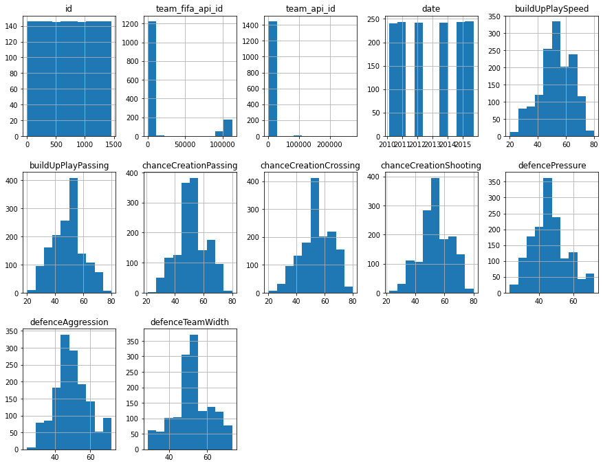

```python
# histogram of team attributes
team_attr_df.hist(layout = (5,5),figsize=(15,20));
```

### match_df

```python
match_df = pd.read_csv("match.csv") #read match.csv
```

```python
match_df.shape
```

```
(25979, 115)
```

```python
match_df.head()
```

|  | id | country_id | league_id | season | stage | date | match_api_id | home_team_api_id | away_team_api_id | home_team_goal | ... | SJA | VCH | VCD | VCA | GBH | GBD | GBA | BSH | BSD | BSA |
| --- | --- | --- | --- | --- | --- | --- | --- | --- | --- | --- | --- | --- | --- | --- | --- | --- | --- | --- | --- | --- | --- |
| 0 | 1 | 1 | 1 | 2008/2009 | 1 | 2008-08-17 00:00:00 | 492473 | 9987 | 9993 | 1 | ... | 4.00 | 1.65 | 3.40 | 4.50 | 1.78 | 3.25 | 4.00 | 1.73 | 3.40 | 4.20 |
| 1 | 2 | 1 | 1 | 2008/2009 | 1 | 2008-08-16 00:00:00 | 492474 | 10000 | 9994 | 0 | ... | 3.80 | 2.00 | 3.25 | 3.25 | 1.85 | 3.25 | 3.75 | 1.91 | 3.25 | 3.60 |
| 2 | 3 | 1 | 1 | 2008/2009 | 1 | 2008-08-16 00:00:00 | 492475 | 9984 | 8635 | 0 | ... | 2.50 | 2.35 | 3.25 | 2.65 | 2.50 | 3.20 | 2.50 | 2.30 | 3.20 | 2.75 |
| 3 | 4 | 1 | 1 | 2008/2009 | 1 | 2008-08-17 00:00:00 | 492476 | 9991 | 9998 | 5 | ... | 7.50 | 1.45 | 3.75 | 6.50 | 1.50 | 3.75 | 5.50 | 1.44 | 3.75 | 6.50 |
| 4 | 5 | 1 | 1 | 2008/2009 | 1 | 2008-08-16 00:00:00 | 492477 | 7947 | 9985 | 1 | ... | 1.73 | 4.50 | 3.40 | 1.65 | 4.50 | 3.50 | 1.65 | 4.75 | 3.30 | 1.67 |

5 rows × 115 columns

```python
# summary statistics
match_df.describe()
```

|  | id | country_id | league_id | stage | match_api_id | home_team_api_id | away_team_api_id | home_team_goal | away_team_goal | home_player_X1 | ... | SJA | VCH | VCD | VCA | GBH | GBD | GBA | BSH | BSD | BSA |
| --- | --- | --- | --- | --- | --- | --- | --- | --- | --- | --- | --- | --- | --- | --- | --- | --- | --- | --- | --- | --- | --- |
| count | 25979.000000 | 25979.000000 | 25979.000000 | 25979.000000 | 2.597900e+04 | 25979.000000 | 25979.000000 | 25979.000000 | 25979.000000 | 24158.000000 | ... | 17097.000000 | 22568.000000 | 22568.000000 | 22568.000000 | 14162.000000 | 14162.000000 | 14162.000000 | 14161.000000 | 14161.000000 | 14161.000000 |
| mean | 12990.000000 | 11738.630317 | 11738.630317 | 18.242773 | 1.195429e+06 | 9984.371993 | 9984.475115 | 1.544594 | 1.160938 | 0.999586 | ... | 4.622343 | 2.668107 | 3.899048 | 4.840281 | 2.498764 | 3.648189 | 4.353097 | 2.497894 | 3.660742 | 4.405663 |
| std | 7499.635658 | 7553.936759 | 7553.936759 | 10.407354 | 4.946279e+05 | 14087.453758 | 14087.445135 | 1.297158 | 1.142110 | 0.022284 | ... | 3.632164 | 1.928753 | 1.248221 | 4.318338 | 1.489299 | 0.867440 | 3.010189 | 1.507793 | 0.868272 | 3.189814 |
| min | 1.000000 | 1.000000 | 1.000000 | 1.000000 | 4.831290e+05 | 1601.000000 | 1601.000000 | 0.000000 | 0.000000 | 0.000000 | ... | 1.100000 | 1.030000 | 1.620000 | 1.080000 | 1.050000 | 1.450000 | 1.120000 | 1.040000 | 1.330000 | 1.120000 |
| 25% | 6495.500000 | 4769.000000 | 4769.000000 | 9.000000 | 7.684365e+05 | 8475.000000 | 8475.000000 | 1.000000 | 0.000000 | 1.000000 | ... | 2.500000 | 1.700000 | 3.300000 | 2.550000 | 1.670000 | 3.200000 | 2.500000 | 1.670000 | 3.250000 | 2.500000 |
| 50% | 12990.000000 | 10257.000000 | 10257.000000 | 18.000000 | 1.147511e+06 | 8697.000000 | 8697.000000 | 1.000000 | 1.000000 | 1.000000 | ... | 3.500000 | 2.150000 | 3.500000 | 3.500000 | 2.100000 | 3.300000 | 3.400000 | 2.100000 | 3.400000 | 3.400000 |
| 75% | 19484.500000 | 17642.000000 | 17642.000000 | 27.000000 | 1.709852e+06 | 9925.000000 | 9925.000000 | 2.000000 | 2.000000 | 1.000000 | ... | 5.250000 | 2.800000 | 4.000000 | 5.400000 | 2.650000 | 3.750000 | 5.000000 | 2.620000 | 3.750000 | 5.000000 |
| max | 25979.000000 | 24558.000000 | 24558.000000 | 38.000000 | 2.216672e+06 | 274581.000000 | 274581.000000 | 10.000000 | 9.000000 | 2.000000 | ... | 41.000000 | 36.000000 | 26.000000 | 67.000000 | 21.000000 | 11.000000 | 34.000000 | 17.000000 | 13.000000 | 34.000000 |

8 rows × 105 columns

```python
# get column names and indices
for i, j in enumerate(match_df.columns):
    print(i, j)
```

```
0 id
1 country_id
2 league_id
3 season
4 stage
5 date
6 match_api_id
7 home_team_api_id
8 away_team_api_id
9 home_team_goal
10 away_team_goal
11 home_player_X1
12 home_player_X2
13 home_player_X3
14 home_player_X4
```

[output cut: 100 more lines]

```python
# too many columns check first 30
match_df.info(20)
```

```
<class 'pandas.core.frame.DataFrame'>
RangeIndex: 25979 entries, 0 to 25978
Data columns (total 115 columns):
 #    Column            Dtype
---   ------            -----
 0    id                int64
 1    country_id        int64
 2    league_id         int64
 3    season            object
 4    stage             int64
 5    date              object
 6    match_api_id      int64
 7    home_team_api_id  int64
 8    away_team_api_id  int64
 9    home_team_goal    int64
```

[output cut: 107 more lines]

```python
match_df.columns[85:]
```

```
Index(['B365H', 'B365D', 'B365A', 'BWH', 'BWD', 'BWA', 'IWH', 'IWD', 'IWA',
       'LBH', 'LBD', 'LBA', 'PSH', 'PSD', 'PSA', 'WHH', 'WHD', 'WHA', 'SJH',
       'SJD', 'SJA', 'VCH', 'VCD', 'VCA', 'GBH', 'GBD', 'GBA', 'BSH', 'BSD',
       'BSA'],
      dtype='object')
```

```python
# drop betting columns

match_df.drop(match_df.columns[85:], axis=1, inplace=True)
```

```python
# check columns with missing values
match_df.loc[:,match_df.isna().any()].columns
```

```
Index(['home_player_X1', 'home_player_X2', 'home_player_X3', 'home_player_X4',
       'home_player_X5', 'home_player_X6', 'home_player_X7', 'home_player_X8',
       'home_player_X9', 'home_player_X10', 'home_player_X11',
       'away_player_X1', 'away_player_X2', 'away_player_X3', 'away_player_X4',
       'away_player_X5', 'away_player_X6', 'away_player_X7', 'away_player_X8',
       'away_player_X9', 'away_player_X10', 'away_player_X11',
       'home_player_Y1', 'home_player_Y2', 'home_player_Y3', 'home_player_Y4',
       'home_player_Y5', 'home_player_Y6', 'home_player_Y7', 'home_player_Y8',
       'home_player_Y9', 'home_player_Y10', 'home_player_Y11',
       'away_player_Y1', 'away_player_Y2', 'away_player_Y3', 'away_player_Y4',
       'away_player_Y5', 'away_player_Y6', 'away_player_Y7', 'away_player_Y8',
       'away_player_Y9', 'away_player_Y10', 'away_player_Y11', 'home_player_1',
       'home_player_2', 'home_player_3', 'home_player_4', 'home_player_5',
       'home_player_6', 'home_player_7', 'home_player_8', 'home_player_9',
       'home_player_10', 'home_player_11', 'away_player_1', 'away_player_2',
       'away_player_3', 'away_player_4', 'away_player_5', 'away_player_6',
       'away_player_7', 'away_player_8', 'away_player_9', 'away_player_10',
       'away_player_11', 'goal', 'shoton', 'shotoff', 'foulcommit', 'card',
       'cross', 'corner', 'possession'],
      dtype='object')
```

```python
# get frequency of missing values in each column
print(match_df.isna().sum()/len(match_df)*100)
```

```
id             0.00000
country_id     0.00000
league_id      0.00000
season         0.00000
stage          0.00000
                ...
foulcommit    45.27503
card          45.27503
cross         45.27503
corner        45.27503
possession    45.27503
Length: 85, dtype: float64
```

```python
for i, j in enumerate(match_df):
    print(i, j, match_df[j].isna().sum()/len(match_df)*100)
```

```
0 id 0.0
1 country_id 0.0
2 league_id 0.0
3 season 0.0
4 stage 0.0
5 date 0.0
6 match_api_id 0.0
7 home_team_api_id 0.0
8 away_team_api_id 0.0
9 home_team_goal 0.0
10 away_team_goal 0.0
11 home_player_X1 7.009507679279419
12 home_player_X2 7.009507679279419
13 home_player_X3 7.051849570807191
14 home_player_X4 7.051849570807191
```

[output cut: 70 more lines]

```python
# inspect missing values > 20%
print('***Printing goal column unique values***\n')
print(match_df['goal'].unique()[:2])
print('\n'*2)
print('***Printing shoton column unique values***\n')
print(match_df['shoton'].unique()[:2])
print('\n'*2)
print('***Printing foulcommit column unique values***\n')
print(match_df['foulcommit'].unique()[:2])
print('\n'*2)
print('***Printing card column unique values***\n')
print(match_df['card'].unique()[:2])
print('\n'*2)
print('***Printing cross column unique values***\n')
print(match_df['cross'].unique()[:2])
print('\n'*2)
print('***Printing corner column unique values***\n')
print(match_df['corner'].unique()[:2])
print('\n'*2)
print('***Printing possession column unique values***\n')
print(match_df['possession'].unique()[:2])

# data were scraped with a lot of noise
```

```
***Printing goal column unique values***

[nan
 '<goal><value><comment>n</comment><stats><goals>1</goals><shoton>1</shoton></stats><event_incident_typefk>406</event_incident_typefk><elapsed>22</elapsed><player2>38807</player2><subtype>header</subtype><player1>37799</player1><sortorder>5</sortorder><team>10261</team><id>378998</id><n>295</n><type…



***Printing shoton column unique values***

[nan
 '<shoton><value><stats><blocked>1</blocked></stats><event_incident_typefk>61</event_incident_typefk><elapsed>3</elapsed><subtype>blocked_shot</subtype><player1>24154</player1><sortorder>0</sortorder><team>10260</team><n>253</n><type>shoton</type><id>378828</id></value><value><stats><shoton>1</shoto…



***Printing foulcommit column unique values***

[nan
 '<foulcommit><value><stats><foulscommitted>1</foulscommitted></stats><event_incident_typefk>37</event_incident_typefk><elapsed>1</elapsed><player2>32569</player2><player1>25518</player1><sortorder>1</sortorder><team>10261</team><n>267</n><type>foulcommit</type><id>378824</id></value><value><stats><…



***Printing card column unique values***

[nan
 '<card><value><comment>y</comment><stats><ycards>1</ycards></stats><event_incident_typefk>73</event_incident_typefk><elapsed>78</elapsed><card_type>y</card_type><subtype>serious_fouls</subtype><player1>24157</player1><sortorder>1</sortorder><team>10260</team><n>342</n><type>card</type><id>379481</i…



***Printing cross column unique values***

[nan
 '<cross><value><stats><crosses>1</crosses></stats><event_incident_typefk>7</event_incident_typefk><elapsed>7</elapsed><subtype>cross</subtype><player1>30829</player1><sortorder>1</sortorder><team>10260</team><n>265</n><type>cross</type><id>378863</id></value><value><stats><crosses>1</crosses></stat…



***Printing corner column unique values***

[nan
 '<corner><value><stats><corners>1</corners></stats><event_incident_typefk>329</event_incident_typefk><elapsed>19</elapsed><subtype>cross</subtype><player1>38807</player1><sortorder>0</sortorder><team>10261</team><n>280</n><type>corner</type><id>378960</id></value><value><stats><corners>1</corners><…



***Printing possession column unique values***

[nan
 '<possession><value><comment>56</comment><event_incident_typefk>352</event_incident_typefk><elapsed>25</elapsed><subtype>possession</subtype><sortorder>1</sortorder><awaypos>44</awaypos><homepos>56</homepos><n>68</n><type>special</type><id>379029</id></value><value><comment>54</comment><elapsed_plu…
```

```python
match_df['home_player_Y1'].unique()
```

```
array([nan,  1.,  3.,  0.])
```

```python
match_df['home_player_X2'].unique()
```

```
array([nan,  2.,  4.,  3.,  1.,  5.,  6.,  8.,  7.,  0.])
```

```python
match_df['away_player_Y1'].unique()
```

```
array([nan,  1.,  3.])
```

```python
# drop unexplainable and coordinates columns
match_df.drop(match_df.columns[np.r_[11:55, 77:85]], axis=1, inplace=True)
```

```python
# check missing values
for i, j in enumerate(match_df):
    print(i, j, match_df[j].isna().sum()/len(match_df)*100)
```

```
0 id 0.0
1 country_id 0.0
2 league_id 0.0
3 season 0.0
4 stage 0.0
5 date 0.0
6 match_api_id 0.0
7 home_team_api_id 0.0
8 away_team_api_id 0.0
9 home_team_goal 0.0
10 away_team_goal 0.0
11 home_player_1 4.711497748181223
12 home_player_2 5.0617806690018865
13 home_player_3 4.930905731552407
14 home_player_4 5.092574771931175
```

[output cut: 18 more lines]

```python
match_df['home_player_1'].unique()
match_df['away_player_2'].unique()
```

```
array([    nan,  38388.,  38293., ...,  27232., 458806.,  92252.])
```

```python
# missing values on *_player_number indicates the participation of a player in a particular match

match_df.iloc[:,np.r_[9:11,11:33]]
```

|  | home_team_goal | away_team_goal | home_player_1 | home_player_2 | home_player_3 | home_player_4 | home_player_5 | home_player_6 | home_player_7 | home_player_8 | ... | away_player_2 | away_player_3 | away_player_4 | away_player_5 | away_player_6 | away_player_7 | away_player_8 | away_player_9 | away_player_10 | away_player_11 |
| --- | --- | --- | --- | --- | --- | --- | --- | --- | --- | --- | --- | --- | --- | --- | --- | --- | --- | --- | --- | --- | --- |
| 0 | 1 | 1 | NaN | NaN | NaN | NaN | NaN | NaN | NaN | NaN | ... | NaN | NaN | NaN | NaN | NaN | NaN | NaN | NaN | NaN | NaN |
| 1 | 0 | 0 | NaN | NaN | NaN | NaN | NaN | NaN | NaN | NaN | ... | NaN | NaN | NaN | NaN | NaN | NaN | NaN | NaN | NaN | NaN |
| 2 | 0 | 3 | NaN | NaN | NaN | NaN | NaN | NaN | NaN | NaN | ... | NaN | NaN | NaN | NaN | NaN | NaN | NaN | NaN | NaN | NaN |
| 3 | 5 | 0 | NaN | NaN | NaN | NaN | NaN | NaN | NaN | NaN | ... | NaN | NaN | NaN | NaN | NaN | NaN | NaN | NaN | NaN | NaN |
| 4 | 1 | 3 | NaN | NaN | NaN | NaN | NaN | NaN | NaN | NaN | ... | NaN | NaN | NaN | NaN | NaN | NaN | NaN | NaN | NaN | NaN |
| ... | ... | ... | ... | ... | ... | ... | ... | ... | ... | ... | ... | ... | ... | ... | ... | ... | ... | ... | ... | ... | ... |
| 25974 | 1 | 0 | 42231.0 | 678384.0 | 95220.0 | 638592.0 | 413155.0 | 45780.0 | 171229.0 | 67333.0 | ... | 563066.0 | 8800.0 | 67304.0 | 158253.0 | 133126.0 | 186524.0 | 93223.0 | 121115.0 | 232110.0 | 289732.0 |
| 25975 | 1 | 2 | 33272.0 | 41621.0 | 25813.0 | 257845.0 | 114735.0 | 42237.0 | 113227.0 | 358156.0 | ... | 114792.0 | 150007.0 | 178119.0 | 27232.0 | 570830.0 | 260708.0 | 201704.0 | 36382.0 | 34082.0 | 95257.0 |
| 25976 | 2 | 0 | 157856.0 | 274779.0 | 177689.0 | 294256.0 | 42258.0 | 39979.0 | 173936.0 | 147959.0 | ... | 67349.0 | 202663.0 | 32597.0 | 114794.0 | 188114.0 | 25840.0 | 482200.0 | 95230.0 | 451335.0 | 275122.0 |
| 25977 | 0 | 0 | NaN | 8881.0 | 173534.0 | 39646.0 | 282287.0 | 340790.0 | 393337.0 | 8893.0 | ... | 121080.0 | 197757.0 | 260964.0 | 231614.0 | 113235.0 | 41116.0 | 462608.0 | 42262.0 | 92252.0 | 194532.0 |
| 25978 | 4 | 3 | 274787.0 | 492132.0 | 108451.0 | 25815.0 | 94553.0 | 384376.0 | 598355.0 | 36785.0 | ... | 95216.0 | 172768.0 | 22834.0 | 458806.0 | 207234.0 | 25772.0 | 40274.0 | 34035.0 | 41726.0 | 527103.0 |

25979 rows × 24 columns

```python
# filling missing values with 0
match_df.fillna(0, inplace=True)
```

```python
match_df.shape
```

```
(25979, 33)
```

```python
match_df.info()
```

```
<class 'pandas.core.frame.DataFrame'>
RangeIndex: 25979 entries, 0 to 25978
Data columns (total 33 columns):
 #   Column            Non-Null Count  Dtype
---  ------            --------------  -----
 0   id                25979 non-null  int64
 1   country_id        25979 non-null  int64
 2   league_id         25979 non-null  int64
 3   season            25979 non-null  object
 4   stage             25979 non-null  int64
 5   date              25979 non-null  object
 6   match_api_id      25979 non-null  int64
 7   home_team_api_id  25979 non-null  int64
 8   away_team_api_id  25979 non-null  int64
 9   home_team_goal    25979 non-null  int64
```

[output cut: 25 more lines]

```python
# check duplicates
match_df.duplicated().sum()
```

```
0
```

```python
# convert date to datetime
match_df['date'] = pd.to_datetime(match_df['date'])
```

```python
match_df.info()
```

```
<class 'pandas.core.frame.DataFrame'>
RangeIndex: 25979 entries, 0 to 25978
Data columns (total 33 columns):
 #   Column            Non-Null Count  Dtype
---  ------            --------------  -----
 0   id                25979 non-null  int64
 1   country_id        25979 non-null  int64
 2   league_id         25979 non-null  int64
 3   season            25979 non-null  object
 4   stage             25979 non-null  int64
 5   date              25979 non-null  datetime64[ns]
 6   match_api_id      25979 non-null  int64
 7   home_team_api_id  25979 non-null  int64
 8   away_team_api_id  25979 non-null  int64
 9   home_team_goal    25979 non-null  int64
```

[output cut: 25 more lines]

```python
# convert players column to int
match_df[match_df.columns[11:33]] = match_df[match_df.columns[11:33]].apply(lambda x: x.astype(int))
```

```python
match_df.info()
```

```
<class 'pandas.core.frame.DataFrame'>
RangeIndex: 25979 entries, 0 to 25978
Data columns (total 33 columns):
 #   Column            Non-Null Count  Dtype
---  ------            --------------  -----
 0   id                25979 non-null  int64
 1   country_id        25979 non-null  int64
 2   league_id         25979 non-null  int64
 3   season            25979 non-null  object
 4   stage             25979 non-null  int64
 5   date              25979 non-null  datetime64[ns]
 6   match_api_id      25979 non-null  int64
 7   home_team_api_id  25979 non-null  int64
 8   away_team_api_id  25979 non-null  int64
 9   home_team_goal    25979 non-null  int64
```

[output cut: 25 more lines]

### players_df

```python
players_df = pd.read_csv("player.csv") #read players.csv
```

```python
players_df.info()
```

```
<class 'pandas.core.frame.DataFrame'>
RangeIndex: 11060 entries, 0 to 11059
Data columns (total 7 columns):
 #   Column              Non-Null Count  Dtype
---  ------              --------------  -----
 0   id                  11060 non-null  int64
 1   player_api_id       11060 non-null  int64
 2   player_name         11060 non-null  object
 3   player_fifa_api_id  11060 non-null  int64
 4   birthday            11060 non-null  object
 5   height              11060 non-null  float64
 6   weight              11060 non-null  int64
dtypes: float64(1), int64(4), object(2)
memory usage: 605.0+ KB
```

```python
players_df.shape
```

```
(11060, 7)
```

```python
players_df.head()
```

|  | id | player_api_id | player_name | player_fifa_api_id | birthday | height | weight |
| --- | --- | --- | --- | --- | --- | --- | --- |
| 0 | 1 | 505942 | Aaron Appindangoye | 218353 | 1992-02-29 00:00:00 | 182.88 | 187 |
| 1 | 2 | 155782 | Aaron Cresswell | 189615 | 1989-12-15 00:00:00 | 170.18 | 146 |
| 2 | 3 | 162549 | Aaron Doran | 186170 | 1991-05-13 00:00:00 | 170.18 | 163 |
| 3 | 4 | 30572 | Aaron Galindo | 140161 | 1982-05-08 00:00:00 | 182.88 | 198 |
| 4 | 5 | 23780 | Aaron Hughes | 17725 | 1979-11-08 00:00:00 | 182.88 | 154 |

```python
# get column names and indices
for i, j in enumerate(players_df.columns):
    print(i, j)
```

```
0 id
1 player_api_id
2 player_name
3 player_fifa_api_id
4 birthday
5 height
6 weight
```

```python
# get columns with missing values

players_df.loc[:, players_df.isna().any()].columns
```

```
Index([], dtype='object')
```

```python
# percentage of missing value in each column

players_df.isna().sum()/len(players_df)*100
```

```
id                    0.0
player_api_id         0.0
player_name           0.0
player_fifa_api_id    0.0
birthday              0.0
height                0.0
weight                0.0
dtype: float64
```

```python
players_df
```

|  | id | player_api_id | player_name | player_fifa_api_id | birthday | height | weight |
| --- | --- | --- | --- | --- | --- | --- | --- |
| 0 | 1 | 505942 | Aaron Appindangoye | 218353 | 1992-02-29 00:00:00 | 182.88 | 187 |
| 1 | 2 | 155782 | Aaron Cresswell | 189615 | 1989-12-15 00:00:00 | 170.18 | 146 |
| 2 | 3 | 162549 | Aaron Doran | 186170 | 1991-05-13 00:00:00 | 170.18 | 163 |
| 3 | 4 | 30572 | Aaron Galindo | 140161 | 1982-05-08 00:00:00 | 182.88 | 198 |
| 4 | 5 | 23780 | Aaron Hughes | 17725 | 1979-11-08 00:00:00 | 182.88 | 154 |
| ... | ... | ... | ... | ... | ... | ... | ... |
| 11055 | 11071 | 26357 | Zoumana Camara | 2488 | 1979-04-03 00:00:00 | 182.88 | 168 |
| 11056 | 11072 | 111182 | Zsolt Laczko | 164680 | 1986-12-18 00:00:00 | 182.88 | 176 |
| 11057 | 11073 | 36491 | Zsolt Low | 111191 | 1979-04-29 00:00:00 | 180.34 | 154 |
| 11058 | 11074 | 35506 | Zurab Khizanishvili | 47058 | 1981-10-06 00:00:00 | 185.42 | 172 |
| 11059 | 11075 | 39902 | Zvjezdan Misimovic | 102359 | 1982-06-05 00:00:00 | 180.34 | 176 |

11060 rows × 7 columns

```python
# check for duplicates
players_df.duplicated().sum()
```

```
0
```

```python
players_df.shape
```

```
(11060, 7)
```

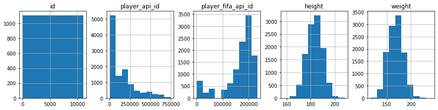

```python
# histogram of players
players_df.hist(layout = (5,5),figsize=(15,20));
```

### players_attr_df

```python
players_attr_df = pd.read_csv("player_attributes.csv") # read players attribute csv
```

```python
players_attr_df.info()
```

```
<class 'pandas.core.frame.DataFrame'>
RangeIndex: 183978 entries, 0 to 183977
Data columns (total 42 columns):
 #   Column               Non-Null Count   Dtype
---  ------               --------------   -----
 0   id                   183978 non-null  int64
 1   player_fifa_api_id   183978 non-null  int64
 2   player_api_id        183978 non-null  int64
 3   date                 183978 non-null  object
 4   overall_rating       183142 non-null  float64
 5   potential            183142 non-null  float64
 6   preferred_foot       183142 non-null  object
 7   attacking_work_rate  180748 non-null  object
 8   defensive_work_rate  183142 non-null  object
 9   crossing             183142 non-null  float64
```

[output cut: 34 more lines]

```python
players_attr_df.shape
```

```
(183978, 42)
```

```python
players_attr_df.head()
```

|  | id | player_fifa_api_id | player_api_id | date | overall_rating | potential | preferred_foot | attacking_work_rate | defensive_work_rate | crossing | ... | vision | penalties | marking | standing_tackle | sliding_tackle | gk_diving | gk_handling | gk_kicking | gk_positioning | gk_reflexes |
| --- | --- | --- | --- | --- | --- | --- | --- | --- | --- | --- | --- | --- | --- | --- | --- | --- | --- | --- | --- | --- | --- |
| 0 | 1 | 218353 | 505942 | 2016-02-18 00:00:00 | 67.0 | 71.0 | right | medium | medium | 49.0 | ... | 54.0 | 48.0 | 65.0 | 69.0 | 69.0 | 6.0 | 11.0 | 10.0 | 8.0 | 8.0 |
| 1 | 2 | 218353 | 505942 | 2015-11-19 00:00:00 | 67.0 | 71.0 | right | medium | medium | 49.0 | ... | 54.0 | 48.0 | 65.0 | 69.0 | 69.0 | 6.0 | 11.0 | 10.0 | 8.0 | 8.0 |
| 2 | 3 | 218353 | 505942 | 2015-09-21 00:00:00 | 62.0 | 66.0 | right | medium | medium | 49.0 | ... | 54.0 | 48.0 | 65.0 | 66.0 | 69.0 | 6.0 | 11.0 | 10.0 | 8.0 | 8.0 |
| 3 | 4 | 218353 | 505942 | 2015-03-20 00:00:00 | 61.0 | 65.0 | right | medium | medium | 48.0 | ... | 53.0 | 47.0 | 62.0 | 63.0 | 66.0 | 5.0 | 10.0 | 9.0 | 7.0 | 7.0 |
| 4 | 5 | 218353 | 505942 | 2007-02-22 00:00:00 | 61.0 | 65.0 | right | medium | medium | 48.0 | ... | 53.0 | 47.0 | 62.0 | 63.0 | 66.0 | 5.0 | 10.0 | 9.0 | 7.0 | 7.0 |

5 rows × 42 columns

```python
# get columns with missing values

players_attr_df.loc[:, players_attr_df.isna().any()].columns
```

```
Index(['overall_rating', 'potential', 'preferred_foot', 'attacking_work_rate',
       'defensive_work_rate', 'crossing', 'finishing', 'heading_accuracy',
       'short_passing', 'volleys', 'dribbling', 'curve', 'free_kick_accuracy',
       'long_passing', 'ball_control', 'acceleration', 'sprint_speed',
       'agility', 'reactions', 'balance', 'shot_power', 'jumping', 'stamina',
       'strength', 'long_shots', 'aggression', 'interceptions', 'positioning',
       'vision', 'penalties', 'marking', 'standing_tackle', 'sliding_tackle',
       'gk_diving', 'gk_handling', 'gk_kicking', 'gk_positioning',
       'gk_reflexes'],
      dtype='object')
```

```python
# percentage of missing value in each column

players_attr_df.isna().sum()/len(players_attr_df)*100
```

```
id                     0.000000
player_fifa_api_id     0.000000
player_api_id          0.000000
date                   0.000000
overall_rating         0.454402
potential              0.454402
preferred_foot         0.454402
attacking_work_rate    1.755645
defensive_work_rate    0.454402
crossing               0.454402
finishing              0.454402
heading_accuracy       0.454402
short_passing          0.454402
volleys                1.474633
dribbling              0.454402
curve                  1.474633
free_kick_accuracy     0.454402
long_passing           0.454402
ball_control           0.454402
acceleration           0.454402
sprint_speed           0.454402
agility                1.474633
reactions              0.454402
balance                1.474633
shot_power             0.454402
jumping                1.474633
stamina                0.454402
strength               0.454402
long_shots             0.454402
aggression             0.454402
interceptions          0.454402
positioning            0.454402
vision                 1.474633
penalties              0.454402
marking                0.454402
standing_tackle        0.454402
sliding_tackle         1.474633
gk_diving              0.454402
gk_handling            0.454402
gk_kicking             0.454402
gk_positioning         0.454402
gk_reflexes            0.454402
dtype: float64
```

```python
# print unique column values
for i, cname in enumerate(players_attr_df.columns[4:]):
    print(cname, players_attr_df[cname].unique())
```

```
overall_rating [67. 62. 61. 74. 73. 71. 70. 69. 68. 65. 64. 54. 51. 52. 47. 53. 66. 59.
 75. 72. 76. 78. 77. 79. 60. 80. 81. 82. 84. 48. 63. 83. 55. 58. 50. 56.
 nan 49. 57. 42. 46. 45. 85. 44. 86. 89. 87. 88. 91. 40. 90. 41. 43. 38.
 93. 92. 39. 33. 36. 37. 35. 94.]
potential [71. 66. 65. 76. 75. 77. 78. 79. 80. 68. 64. 60. 67. 70. 72. 69. 82. 73.
 74. 81. 83. 86. 84. 85. 87. 90. 56. 57. 63. 62. 61. nan 59. 55. 58. 53.
 89. 54. 88. 52. 91. 92. 93. 51. 46. 44. 50. 47. 45. 95. 94. 48. 49. 42.
 97. 96. 39.]
preferred_foot ['right' 'left' nan]
attacking_work_rate ['medium' 'high' nan 'low' 'None' 'le' 'norm' 'stoc' 'y']
defensive_work_rate ['medium' 'high' 'low' '_0' nan '5' 'ean' 'o' '1' 'ormal' '7' '2' '8' '4'
 'tocky' '0' '3' '6' '9' 'es']
crossing [49. 48. 80. 79. 78. 77. 74. 58. 57. 22. 64. 65. 67. 69. 72. 73. 63. 56.
 59. 60. 46. 45. 75. 76. 47. 82. 71. 12. 62. 26. 70. 66. 40. 53. 55. 54.
 61. 39. 41. 42. 52. 68. nan 35. 34. 50. 38. 84. 81. 25. 11.  6. 23. 29.
 36. 44. 43. 51. 32. 33. 15. 14.  9. 21. 28. 20. 37. 19. 18. 83.  8. 31.
 24. 92. 10. 30. 27. 86. 90. 88. 13. 17. 85. 87. 16. 91. 93.  3. 89.  7.
  5.  4. 94. 95.  2.  1.]
finishing [44. 43. 53. 52. 51. 50. 40. 39. 48. 58. 56. 61. 69. 21. 20. 34. 33. 57.
 72. 73. 74. 71. 77. 79. 32. 31. 66. 65. 67. 68. 70. 62. 64. 15. 42. 41.
 45. 63. 54. 23. 75. 76. 26. 25. 55. 29. 17. 16. 22. 60. 37. nan 30. 49.
 47. 46. 38. 28. 27. 80. 78. 11. 10. 18. 59. 36. 82. 13.  9.  5.  8. 35.
 14. 24. 81. 88. 92. 83. 84. 86. 90. 89. 93. 85. 19.  6.  3. 12.  4. 87.
 91.  7.  2.  1. 95. 94. 97. 96.]
heading_accuracy [71. 70. 58. 57. 56. 51. 50. 52. 60. 59. 62. 45. 68. 67. 73. 74. 79. 72.
 76. 64. 65. 66. 47. 46. 28. 27. 38. 49. 16. 61. 82. 42. 54. 53. 63. 55.
 43. 78. 77. 75. 48. 69. 39. 30. 80. nan 81. 84. 13. 25. 12. 23. 41. 44.
 37. 32. 90. 40. 11. 10. 21. 35. 24. 18. 17. 33. 31. 26. 36. 85. 86. 87.
 83. 22. 19. 34. 88. 89. 15.  8. 92. 20. 14.  4. 91.  9.  3. 93. 29.  6.
  7. 95.  5.  1. 94.  2. 98.]
short_passing [61. 60. 71. 70. 69. 67. 64. 62. 59. 45. 44. 39. 66. 68. 63. 65. 53. 72.
 54. 79. 80. 75. 77. 78. 76. 23. 73. 84. 74. 58. 57. 52. 42. 83. 82. 85.
 55. 56. 40. 51. 49. nan 43. 47. 48. 34. 33. 41. 35. 81. 46. 25. 38. 16.
 15. 21. 26. 32. 28. 27. 50. 36. 37. 20. 30.  9. 13. 11. 10.  8. 29. 22.
 12. 86. 87. 89. 18. 19. 88. 31. 90. 92. 24.  3. 93. 91. 94. 95. 97. 14.
 17. 96.  7.  6.  5.  4.]
volleys [44. 43. 40. 32. 29. 28. 30. 52. 51. 56. 63. 48. 47. 33. 77. 80. 34. 68.
 67. 69. 14. 60. 59. 65. 64. 57. 25. 61. 79. 81. 78. 76. 74. 73. 70. 42.
 41. 24. 55. 62. 36. 23. 72. nan 58. 31. 66. 37. 46. 45. 49. 13. 39. 50.
 53. 54. 35. 75. 71. 10. 11.  5. 22. 21. 16. 38. 15. 27. 26. 12. 20.  6.
```

[output cut: 147 more lines]

```
 78. 68. 31. 29. 74. 20. 41. 82. 81. 84. 23.  4. 36. 32. 50. 28. 25. 83.
 86. 37. 77. 30. 80. 34. 24. 40. 26.  1. 95. 96. 97. 89. 90. 88. 18. 91.
 22. 19. 87. 85. 94. 92. 93. 17.]
gk_positioning [ 8.  7.  9. 22. 21. 12. 11. 20. 10. 16. 15.  6. 14. 13. 25. 51. 31. 24.
 23. nan 70. 65. 64. 39.  5.  3.  2. 19. 18. 62. 58. 63. 71. 72. 68. 60.
 50. 57. 53. 54. 59. 69. 67. 66.  4. 75. 76. 74. 61. 55. 56. 79. 78. 77.
 82. 81. 73. 52. 30. 80. 47. 32. 49. 43. 48. 84. 42.  1. 44. 83. 17. 86.
 85. 87. 88. 45. 28. 46. 92. 38. 93. 91. 90. 94. 34. 41. 89. 96. 35. 27.
 37. 29. 33. 26. 36.]
gk_reflexes [ 8.  7. 12. 11. 22. 13. 21. 10. 20.  6. 15. 14.  9. 25. 53. 30.  5. 24.
 23. nan  4. 16. 75. 74.  3.  2. 64. 60. 58. 55. 78. 76. 73. 72. 68. 54.
 69. 63. 62. 66. 56. 80. 86. 85. 84. 81. 79. 52. 70. 18. 67. 71. 65. 59.
 61. 57. 83. 77. 82. 38. 17.  1. 48. 33. 50. 49. 45. 89. 88. 51. 87. 43.
 47. 46. 27. 37. 92. 90. 41. 19. 29. 44. 42. 91. 35. 26. 40. 93. 94. 96.
 32. 34. 31.]
```

```python
# impute median for missing values of quantitave variables, ignore preferred_foot
players_attr_df['overall_rating'].fillna(players_attr_df['overall_rating'].median(), inplace=True)
```

```python
players_attr_df['potential'].fillna(players_attr_df['potential'].median(), inplace=True)
```

```python
# drop working rate
players_attr_df.drop(columns=['attacking_work_rate', 'defensive_work_rate'], inplace=True)
```

```python
players_attr_df.info()
```

```
<class 'pandas.core.frame.DataFrame'>
RangeIndex: 183978 entries, 0 to 183977
Data columns (total 40 columns):
 #   Column              Non-Null Count   Dtype
---  ------              --------------   -----
 0   id                  183978 non-null  int64
 1   player_fifa_api_id  183978 non-null  int64
 2   player_api_id       183978 non-null  int64
 3   date                183978 non-null  object
 4   overall_rating      183978 non-null  float64
 5   potential           183978 non-null  float64
 6   preferred_foot      183142 non-null  object
 7   crossing            183142 non-null  float64
 8   finishing           183142 non-null  float64
 9   heading_accuracy    183142 non-null  float64
```

[output cut: 32 more lines]

```python
# median loop
for c in players_attr_df.columns[7:]:
    players_attr_df[c].fillna(players_attr_df[c].median(), inplace=True)
```

```python
players_attr_df.info() # median imputed
```

```
<class 'pandas.core.frame.DataFrame'>
RangeIndex: 183978 entries, 0 to 183977
Data columns (total 40 columns):
 #   Column              Non-Null Count   Dtype
---  ------              --------------   -----
 0   id                  183978 non-null  int64
 1   player_fifa_api_id  183978 non-null  int64
 2   player_api_id       183978 non-null  int64
 3   date                183978 non-null  object
 4   overall_rating      183978 non-null  float64
 5   potential           183978 non-null  float64
 6   preferred_foot      183142 non-null  object
 7   crossing            183978 non-null  float64
 8   finishing           183978 non-null  float64
 9   heading_accuracy    183978 non-null  float64
```

[output cut: 32 more lines]

```python
# convert float to int

players_attr_df[players_attr_df.columns[np.r_[4,5,7:40]]] = players_attr_df[players_attr_df.columns[np.r_[4,5,7:40]]].apply(lambda x: x.astype('int'))
```

```python
# convert date
players_attr_df['date'] = pd.to_datetime(players_attr_df['date'])
```

```python
players_attr_df.info()
```

```
<class 'pandas.core.frame.DataFrame'>
RangeIndex: 183978 entries, 0 to 183977
Data columns (total 40 columns):
 #   Column              Non-Null Count   Dtype
---  ------              --------------   -----
 0   id                  183978 non-null  int64
 1   player_fifa_api_id  183978 non-null  int64
 2   player_api_id       183978 non-null  int64
 3   date                183978 non-null  datetime64[ns]
 4   overall_rating      183978 non-null  int32
 5   potential           183978 non-null  int32
 6   preferred_foot      183142 non-null  object
 7   crossing            183978 non-null  int32
 8   finishing           183978 non-null  int32
 9   heading_accuracy    183978 non-null  int32
```

[output cut: 32 more lines]

```python
# check for duplicates
players_attr_df.duplicated().sum()
```

```
0
```

```python
players_df.shape
```

```
(11060, 7)
```

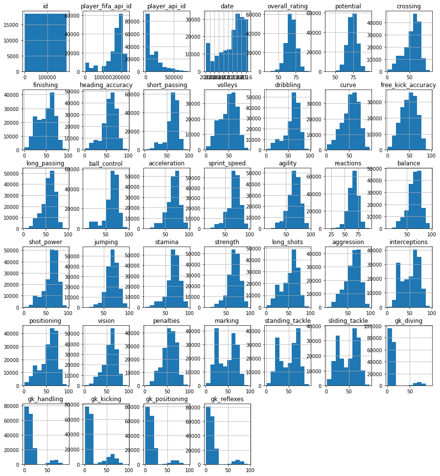

```python
# histogram of players attribute

players_attr_df.hist(layout=(7,7), figsize=(15,20));
```

### league_df

```python
league_df.shape
```

```
(11, 3)
```

```python
league_df.info()
```

```
<class 'pandas.core.frame.DataFrame'>
RangeIndex: 11 entries, 0 to 10
Data columns (total 3 columns):
 #   Column        Non-Null Count  Dtype
---  ------        --------------  -----
 0   country_id    11 non-null     int64
 1   league_name   11 non-null     object
 2   country_name  11 non-null     object
dtypes: int64(1), object(2)
memory usage: 392.0+ bytes
```

```python
league_df.head()
```

|  | country_id | league_name | country_name |
| --- | --- | --- | --- |
| 0 | 1 | Belgium Jupiler League | Belgium |
| 1 | 1729 | England Premier League | England |
| 2 | 4769 | France Ligue 1 | France |
| 3 | 7809 | Germany 1. Bundesliga | Germany |
| 4 | 10257 | Italy Serie A | Italy |

### Check for anomalies

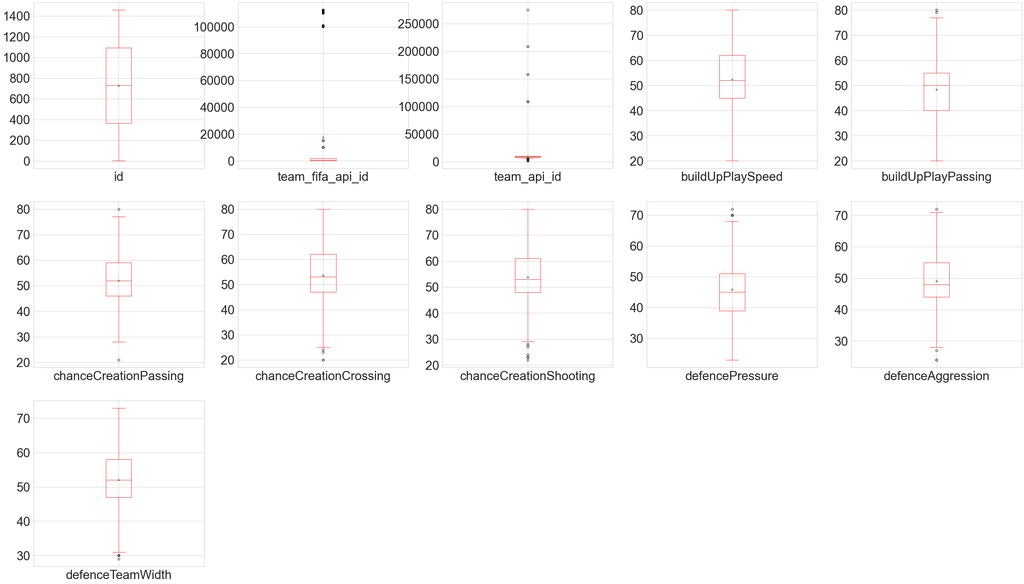

```python
# team attribute boxplot
team_attr_df.plot(subplots=True, layout = (5,5), fontsize=35, kind = 'box',
              color = '#f71212',showmeans = True,figsize = (50,50));
```

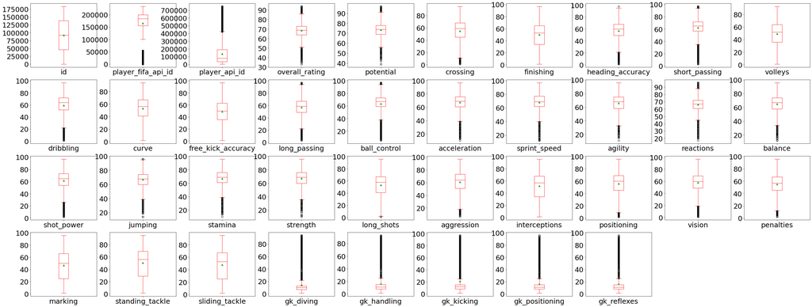

```python
# player attribute boxplot
players_attr_df.plot(subplots=True, layout = (20,10), fontsize=25, kind = 'box',
              color = '#f71212',showmeans = True,figsize = (50,100));
```

### Export clean df to csv

```python
teams_df.to_csv("team_v1.csv", index=False)
team_attr_df.to_csv("team_attri_v1.csv", index=False)
players_df.to_csv("players_v1.csv", index=False)
players_attr_df.to_csv("players_attri_v1.csv", index=False)
match_df.to_csv("match_v1.csv", index=False)
league_df.to_csv("league_v1.csv", index=False)
```

```python
teams_df = pd.read_csv("team_v1.csv")
team_attr_df = pd.read_csv("team_attri_v1.csv")
players_df = pd.read_csv("players_v1.csv")
players_attr_df = pd.read_csv("players_attri_v1.csv")
match_df = pd.read_csv("match_v1.csv")
league_df = pd.read_csv("league_v1.csv")
```

## Exploratory Data Analysis

### Research Question 1: Which team had scored the most goals from 2008 to 2016?

> Goals column is seperated into "home_team_goal" and "away_team_goal" in match_df and each record is identified by team id

> Approach:
> - Merge teams_df with match_df on team id to extract goals
> - Perform addition on home and away goals
> - Group by goals by team name

```python
# merge teams and match for home team
merge_df1 = pd.merge(teams_df, match_df, left_on='team_api_id', right_on="home_team_api_id")
merge_df1
```

|  | id_x | team_api_id | team_long_name | team_short_name | id_y | country_id | league_id | season | stage | date | ... | away_player_2 | away_player_3 | away_player_4 | away_player_5 | away_player_6 | away_player_7 | away_player_8 | away_player_9 | away_player_10 | away_player_11 |
| --- | --- | --- | --- | --- | --- | --- | --- | --- | --- | --- | --- | --- | --- | --- | --- | --- | --- | --- | --- | --- | --- |
| 0 | 1 | 9987 | KRC Genk | GEN | 1 | 1 | 1 | 2008/2009 | 1 | 2008-08-17 | ... | 0 | 0 | 0 | 0 | 0 | 0 | 0 | 0 | 0 | 0 |
| 1 | 1 | 9987 | KRC Genk | GEN | 29 | 1 | 1 | 2008/2009 | 12 | 2008-11-15 | ... | 0 | 0 | 0 | 0 | 0 | 0 | 0 | 0 | 0 | 0 |
| 2 | 1 | 9987 | KRC Genk | GEN | 47 | 1 | 1 | 2008/2009 | 14 | 2008-11-29 | ... | 0 | 0 | 0 | 0 | 0 | 0 | 0 | 0 | 0 | 0 |
| 3 | 1 | 9987 | KRC Genk | GEN | 65 | 1 | 1 | 2008/2009 | 16 | 2008-12-13 | ... | 0 | 0 | 0 | 0 | 0 | 0 | 0 | 0 | 0 | 0 |
| 4 | 1 | 9987 | KRC Genk | GEN | 94 | 1 | 1 | 2008/2009 | 19 | 2009-01-24 | ... | 0 | 0 | 0 | 0 | 0 | 0 | 0 | 0 | 0 | 0 |
| ... | ... | ... | ... | ... | ... | ... | ... | ... | ... | ... | ... | ... | ... | ... | ... | ... | ... | ... | ... | ... | ... |
| 25974 | 51606 | 7896 | Lugano | LUG | 25936 | 24558 | 24558 | 2015/2016 | 34 | 2016-05-16 | ... | 492132 | 108451 | 25815 | 94553 | 245161 | 320184 | 598355 | 45174 | 135247 | 37554 |
| 25975 | 51606 | 7896 | Lugano | LUG | 25946 | 24558 | 24558 | 2015/2016 | 36 | 2016-05-25 | ... | 678384 | 638592 | 413155 | 210423 | 45780 | 176298 | 119839 | 566785 | 92094 | 35831 |
| 25976 | 51606 | 7896 | Lugano | LUG | 25960 | 24558 | 24558 | 2015/2016 | 6 | 2015-08-22 | ... | 30835 | 172768 | 22834 | 181211 | 339992 | 207234 | 25794 | 176206 | 402975 | 527104 |
| 25977 | 51606 | 7896 | Lugano | LUG | 25965 | 24558 | 24558 | 2015/2016 | 7 | 2015-08-29 | ... | 114792 | 150007 | 178119 | 27232 | 185518 | 260708 | 201704 | 95257 | 104646 | 34082 |
| 25978 | 51606 | 7896 | Lugano | LUG | 25978 | 24558 | 24558 | 2015/2016 | 9 | 2015-09-22 | ... | 121080 | 197757 | 260964 | 231614 | 113235 | 41116 | 462608 | 42262 | 92252 | 194532 |

25979 rows × 37 columns

```python
# merge teams and match for away team
merge_df2 = pd.merge(teams_df, match_df, left_on='team_api_id', right_on='away_team_api_id')
merge_df2
```

|  | id_x | team_api_id | team_long_name | team_short_name | id_y | country_id | league_id | season | stage | date | ... | away_player_2 | away_player_3 | away_player_4 | away_player_5 | away_player_6 | away_player_7 | away_player_8 | away_player_9 | away_player_10 | away_player_11 |
| --- | --- | --- | --- | --- | --- | --- | --- | --- | --- | --- | --- | --- | --- | --- | --- | --- | --- | --- | --- | --- | --- |
| 0 | 1 | 9987 | KRC Genk | GEN | 17 | 1 | 1 | 2008/2009 | 10 | 2008-11-01 | ... | 0 | 0 | 0 | 0 | 0 | 0 | 0 | 0 | 0 | 0 |
| 1 | 1 | 9987 | KRC Genk | GEN | 26 | 1 | 1 | 2008/2009 | 11 | 2008-11-08 | ... | 0 | 0 | 0 | 0 | 0 | 0 | 0 | 0 | 0 | 0 |
| 2 | 1 | 9987 | KRC Genk | GEN | 42 | 1 | 1 | 2008/2009 | 13 | 2008-11-23 | ... | 0 | 0 | 0 | 0 | 0 | 0 | 0 | 0 | 0 | 0 |
| 3 | 1 | 9987 | KRC Genk | GEN | 62 | 1 | 1 | 2008/2009 | 15 | 2008-12-07 | ... | 0 | 0 | 0 | 0 | 0 | 0 | 0 | 0 | 0 | 0 |
| 4 | 1 | 9987 | KRC Genk | GEN | 73 | 1 | 1 | 2008/2009 | 17 | 2008-12-19 | ... | 0 | 0 | 0 | 0 | 0 | 0 | 0 | 0 | 0 | 0 |
| ... | ... | ... | ... | ... | ... | ... | ... | ... | ... | ... | ... | ... | ... | ... | ... | ... | ... | ... | ... | ... | ... |
| 25974 | 51606 | 7896 | Lugano | LUG | 25934 | 24558 | 24558 | 2015/2016 | 33 | 2016-05-11 | ... | 8881 | 173534 | 41415 | 282287 | 491221 | 393337 | 8893 | 178142 | 406283 | 614454 |
| 25975 | 51606 | 7896 | Lugano | LUG | 25942 | 24558 | 24558 | 2015/2016 | 35 | 2016-05-22 | ... | 282287 | 429986 | 41415 | 114212 | 491221 | 393337 | 340790 | 406283 | 614454 | 178142 |
| 25976 | 51606 | 7896 | Lugano | LUG | 25950 | 24558 | 24558 | 2015/2016 | 4 | 2015-08-08 | ... | 282287 | 41415 | 173534 | 0 | 393337 | 491221 | 8893 | 67369 | 491794 | 178142 |
| 25977 | 51606 | 7896 | Lugano | LUG | 25956 | 24558 | 24558 | 2015/2016 | 5 | 2015-08-12 | ... | 282287 | 41415 | 173534 | 114212 | 491221 | 393337 | 8893 | 186948 | 93229 | 178142 |
| 25978 | 51606 | 7896 | Lugano | LUG | 25974 | 24558 | 24558 | 2015/2016 | 8 | 2015-09-13 | ... | 8881 | 39646 | 41415 | 282287 | 491221 | 150084 | 8893 | 140490 | 93229 | 178142 |

25979 rows × 37 columns

```python
# group home goals
goals_home = merge_df1.groupby("team_long_name")['home_team_goal'].sum()
goals_home
```

```
team_long_name
1. FC Kaiserslautern         37
1. FC Köln                  116
1. FC Nürnberg              108
1. FSV Mainz 05             171
AC Ajaccio                   64
                           ...
Xerez Club Deportivo         20
Zagłębie Lubin              116
Zawisza Bydgoszcz            43
Évian Thonon Gaillard FC    105
Śląsk Wrocław               176
Name: home_team_goal, Length: 296, dtype: int64
```

```python
# group away goals
goals_away = merge_df2.groupby("team_long_name")['away_team_goal'].sum()
goals_away
```

```
team_long_name
1. FC Kaiserslautern         35
1. FC Köln                  110
1. FC Nürnberg               85
1. FSV Mainz 05             149
AC Ajaccio                   52
                           ...
Xerez Club Deportivo         18
Zagłębie Lubin               91
Zawisza Bydgoszcz            32
Évian Thonon Gaillard FC     75
Śląsk Wrocław               142
Name: away_team_goal, Length: 296, dtype: int64
```

```python
# merge two df into one
goals_df = pd.DataFrame(goals_home+goals_away).reset_index()
goals_df
```

|  | team_long_name | 0 |
| --- | --- | --- |
| 0 | 1. FC Kaiserslautern | 72 |
| 1 | 1. FC Köln | 226 |
| 2 | 1. FC Nürnberg | 193 |
| 3 | 1. FSV Mainz 05 | 320 |
| 4 | AC Ajaccio | 116 |
| ... | ... | ... |
| 291 | Xerez Club Deportivo | 38 |
| 292 | Zagłębie Lubin | 207 |
| 293 | Zawisza Bydgoszcz | 75 |
| 294 | Évian Thonon Gaillard FC | 180 |
| 295 | Śląsk Wrocław | 318 |

296 rows × 2 columns

```python
# rename columns
goals_df.rename({"team_long_name": "Team", 0:"Goals"}, axis=1, inplace=True)
```

```python
goals_df
```

|  | Team | Goals |
| --- | --- | --- |
| 0 | 1. FC Kaiserslautern | 72 |
| 1 | 1. FC Köln | 226 |
| 2 | 1. FC Nürnberg | 193 |
| 3 | 1. FSV Mainz 05 | 320 |
| 4 | AC Ajaccio | 116 |
| ... | ... | ... |
| 291 | Xerez Club Deportivo | 38 |
| 292 | Zagłębie Lubin | 207 |
| 293 | Zawisza Bydgoszcz | 75 |
| 294 | Évian Thonon Gaillard FC | 180 |
| 295 | Śląsk Wrocław | 318 |

296 rows × 2 columns

```python
# sort
goals_df = goals_df.sort_values(by='Goals', ascending=False)
goals_df[:10]
```

|  | Team | Goals |
| --- | --- | --- |
| 75 | FC Barcelona | 849 |
| 211 | Real Madrid CF | 843 |
| 49 | Celtic | 695 |
| 77 | FC Bayern Munich | 653 |
| 184 | PSV | 652 |
| 15 | Ajax | 647 |
| 76 | FC Basel | 619 |
| 161 | Manchester City | 606 |
| 51 | Chelsea | 583 |
| 162 | Manchester United | 582 |

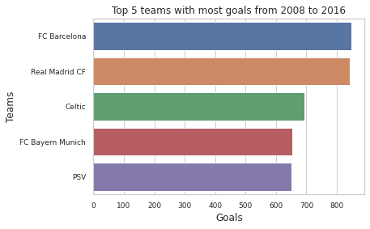

```python
# plot bar chart

# sns.set_style("dark")
sns.set_theme(style="whitegrid")
sns.barplot(x="Goals", y="Team", data=goals_df[:5])
plt.title('Top 5 teams with most goals from 2008 to 2016')
plt.xlabel("Goals")
plt.ylabel("Teams")
plt.tick_params(labelsize=9)
```

> Top team with most goals is "FC Barcelona" amounting to 849 goals. Coming in next is "Real Madrid CF" with 843 goals. Lastly, "Celtic" with 695 goals.

### Research Question 2: What team improved the most over the time period?

> Team attributes like build up, chance creation and defense are located in Team_Attribute dataframe Approach:
> - Merge Team df with Team Attributes to extract Team name
> - Group by merged df by team name on mean of all mentioned attributes and sort them descending
> - plot visuals

```python
team_attr_df.info()
```

```
<class 'pandas.core.frame.DataFrame'>
RangeIndex: 1458 entries, 0 to 1457
Data columns (total 24 columns):
 #   Column                          Non-Null Count  Dtype
---  ------                          --------------  -----
 0   id                              1458 non-null   int64
 1   team_fifa_api_id                1458 non-null   int64
 2   team_api_id                     1458 non-null   int64
 3   date                            1458 non-null   object
 4   buildUpPlaySpeed                1458 non-null   int64
 5   buildUpPlaySpeedClass           1458 non-null   object
 6   buildUpPlayDribblingClass       1458 non-null   object
 7   buildUpPlayPassing              1458 non-null   int64
 8   buildUpPlayPassingClass         1458 non-null   object
 9   buildUpPlayPositioningClass     1458 non-null   object
```

[output cut: 16 more lines]

```python
teams_df.info()
```

```
<class 'pandas.core.frame.DataFrame'>
RangeIndex: 299 entries, 0 to 298
Data columns (total 4 columns):
 #   Column           Non-Null Count  Dtype
---  ------           --------------  -----
 0   id               299 non-null    int64
 1   team_api_id      299 non-null    int64
 2   team_long_name   299 non-null    object
 3   team_short_name  299 non-null    object
dtypes: int64(2), object(2)
memory usage: 9.5+ KB
```

```python
tmerge_df = pd.merge(teams_df, team_attr_df, left_on='team_api_id', right_on='team_api_id')
```

```python
tmerge_df.info()
```

```
<class 'pandas.core.frame.DataFrame'>
Int64Index: 1458 entries, 0 to 1457
Data columns (total 27 columns):
 #   Column                          Non-Null Count  Dtype
---  ------                          --------------  -----
 0   id_x                            1458 non-null   int64
 1   team_api_id                     1458 non-null   int64
 2   team_long_name                  1458 non-null   object
 3   team_short_name                 1458 non-null   object
 4   id_y                            1458 non-null   int64
 5   team_fifa_api_id                1458 non-null   int64
 6   date                            1458 non-null   object
 7   buildUpPlaySpeed                1458 non-null   int64
 8   buildUpPlaySpeedClass           1458 non-null   object
 9   buildUpPlayDribblingClass       1458 non-null   object
```

[output cut: 19 more lines]

```python
team_attr_df.columns
```

```
Index(['id', 'team_fifa_api_id', 'team_api_id', 'date', 'buildUpPlaySpeed',
       'buildUpPlaySpeedClass', 'buildUpPlayDribblingClass',
       'buildUpPlayPassing', 'buildUpPlayPassingClass',
       'buildUpPlayPositioningClass', 'chanceCreationPassing',
       'chanceCreationPassingClass', 'chanceCreationCrossing',
       'chanceCreationCrossingClass', 'chanceCreationShooting',
       'chanceCreationShootingClass', 'chanceCreationPositioningClass',
       'defencePressure', 'defencePressureClass', 'defenceAggression',
       'defenceAggressionClass', 'defenceTeamWidth', 'defenceTeamWidthClass',
       'defenceDefenderLineClass'],
      dtype='object')
```

```python
# groupby team name with respect to their team attribute mean

mask = ['buildUpPlaySpeed','buildUpPlayPassing', 'chanceCreationPassing',
        'chanceCreationCrossing','chanceCreationShooting',
       'defencePressure', 'defenceAggression', 'defenceTeamWidth',
       ]

tmerge_df.groupby('team_long_name')[mask].mean().sort_values(mask, ascending=False).head()
```

| team_long_name | buildUpPlaySpeed | buildUpPlayPassing | chanceCreationPassing | chanceCreationCrossing | chanceCreationShooting | defencePressure | defenceAggression | defenceTeamWidth |
| --- | --- | --- | --- | --- | --- | --- | --- | --- |
| Borussia Dortmund | 72.500000 | 46.5 | 65.000000 | 44.500000 | 66.333333 | 59.333333 | 69.166667 | 46.000000 |
| Udinese | 71.000000 | 53.0 | 61.333333 | 64.833333 | 54.333333 | 40.666667 | 49.333333 | 55.166667 |
| Falkirk | 70.000000 | 70.0 | 60.000000 | 70.000000 | 70.000000 | 60.000000 | 70.000000 | 70.000000 |
| FC Arouca | 67.000000 | 39.0 | 55.000000 | 59.000000 | 46.000000 | 36.000000 | 38.000000 | 37.000000 |
| Bayer 04 Leverkusen | 66.833333 | 48.0 | 59.000000 | 55.833333 | 53.000000 | 57.666667 | 49.500000 | 53.166667 |

```python
# create bar plot for each attribute mean
for i in mask:
    display(tmerge_df.groupby('team_long_name').mean()[i].sort_values(ascending=False).head(5))
```

```
team_long_name
Borussia Dortmund      72.500000
Udinese                71.000000
Falkirk                70.000000
FC Arouca              67.000000
Bayer 04 Leverkusen    66.833333
Name: buildUpPlaySpeed, dtype: float64
```

```
team_long_name
SV Darmstadt 98     77.000000
Falkirk             70.000000
Stoke City          67.000000
Birmingham City     66.000000
Bolton Wanderers    63.833333
Name: buildUpPlayPassing, dtype: float64
```

```
team_long_name
Roma                      68.833333
Crystal Palace            68.500000
Real Madrid CF            67.500000
VfL Wolfsburg             67.000000
Real Sporting de Gijón    66.333333
Name: chanceCreationPassing, dtype: float64
```

```
team_long_name
SV Darmstadt 98            77.000000
Athletic Club de Bilbao    70.166667
Falkirk                    70.000000
BSC Young Boys             68.500000
Granada CF                 68.400000
Name: chanceCreationCrossing, dtype: float64
```

```
team_long_name
Falkirk               70.000000
Odra Wodzisław        70.000000
Brescia               69.833333
Olympique Lyonnais    69.666667
Real Madrid CF        69.000000
Name: chanceCreationShooting, dtype: float64
```

```
team_long_name
Odra Wodzisław       70.000000
KSV Roeselare        65.000000
FC Barcelona         64.333333
Wisła Kraków         61.666667
KSV Cercle Brugge    60.166667
Name: defencePressure, dtype: float64
```

```
team_long_name
Odra Wodzisław       70.000000
KSV Roeselare        70.000000
Falkirk              70.000000
Borussia Dortmund    69.166667
1. FSV Mainz 05      62.500000
Name: defenceAggression, dtype: float64
```

```
team_long_name
KSV Roeselare               70.000000
Falkirk                     70.000000
US Boulogne Cote D'Opale    67.000000
FC Barcelona                66.500000
CA Osasuna                  65.833333
Name: defenceTeamWidth, dtype: float64
```

```python
t_df = tmerge_df.groupby('team_long_name')[mask].mean().sort_values(mask, ascending=False)
```

[figure not shown]

```python
# Consolidate two build up plots into one

fig, axes = plt.subplots(1, 2, figsize=(10,5))
fig.suptitle('Top Teams by Build Up')
axes[0].set_title('Speed')
axes[1].set_title('Passing')

sns.barplot(ax=axes[0], y=t_df[mask[0]].sort_values(ascending=False)[:5], x=t_df[mask[0]].index[:5])
sns.barplot(ax=axes[1], y=t_df[mask[1]].sort_values(ascending=False)[:5], x=t_df[mask[1]].index[:5])

axes[0].set_xticklabels(list(t_df[mask[0]].index[:5]), rotation=45)
axes[1].set_xticklabels(list(t_df[mask[1]].index[:5]), rotation=45)
axes[0].set_ylabel('Speed points')
axes[0].set_xlabel('Team')
axes[1].set_ylabel('Passing points')
axes[1].set_xlabel('Team');
```

[figure not shown]

```python
# Consolidate three chance creation plots into one

fig, axes = plt.subplots(1, 3, figsize=(15,5))
fig.suptitle('Top Teams by Chance Creation')
axes[0].set_title('Passing')
axes[1].set_title('Crossing')
axes[2].set_title('Shooting')

sns.barplot(ax=axes[0], y=t_df[mask[2]].sort_values(ascending=False)[:5], x=t_df[mask[2]].index[:5])
sns.barplot(ax=axes[1], y=t_df[mask[3]].sort_values(ascending=False)[:5], x=t_df[mask[3]].index[:5])
sns.barplot(ax=axes[2], y=t_df[mask[4]].sort_values(ascending=False)[:5], x=t_df[mask[4]].index[:5])

axes[0].set_xticklabels(list(t_df[mask[2]].index[:5]), rotation=45)
axes[1].set_xticklabels(list(t_df[mask[3]].index[:5]), rotation=45)
axes[2].set_xticklabels(list(t_df[mask[4]].index[:5]), rotation=45)
axes[0].set_ylabel('Passing points')
axes[0].set_xlabel('Team')
axes[1].set_ylabel('Crossing points')
axes[1].set_xlabel('Team')
axes[2].set_ylabel('Shooting points')
axes[2].set_xlabel('Team');
```

[figure not shown]

```python
# 'defencePressure', 'defenceAggression', 'defenceTeamWidth'
# Consolidate three defense plots into one

fig, axes = plt.subplots(1, 3, figsize=(15,5))
fig.suptitle('Top Teams by Defense attributes')
axes[0].set_title('Pressure')
axes[1].set_title('Aggression')
axes[2].set_title('Team Width')

sns.barplot(ax=axes[0], y=t_df[mask[5]].sort_values(ascending=False)[:5], x=t_df[mask[5]].index[:5])
sns.barplot(ax=axes[1], y=t_df[mask[6]].sort_values(ascending=False)[:5], x=t_df[mask[6]].index[:5])
sns.barplot(ax=axes[2], y=t_df[mask[7]].sort_values(ascending=False)[:5], x=t_df[mask[7]].index[:5])

axes[0].set_xticklabels(list(t_df[mask[5]].index[:5]), rotation=45)
axes[1].set_xticklabels(list(t_df[mask[6]].index[:5]), rotation=45)
axes[2].set_xticklabels(list(t_df[mask[7]].index[:5]), rotation=45)
axes[0].set_ylabel('Pressure points')
axes[0].set_xlabel('Team')
axes[1].set_ylabel('Aggression points')
axes[1].set_xlabel('Team')
axes[2].set_ylabel('Team Width points')
axes[2].set_xlabel('Team');
```

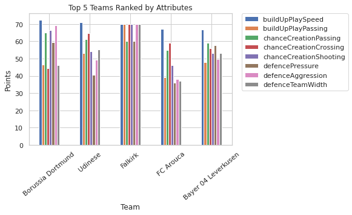

```python
# plot all attributes into one
t_df.head().plot(kind='bar')
plt.xlabel('Team')
plt.ylabel('Points')
plt.title("Top 5 Teams Ranked by Attributes")
plt.xticks(rotation=40)
plt.legend(bbox_to_anchor=(1.05, 1), loc='upper left', borderaxespad=0);
```

### Research Question 3: Which player had the most penalties?

> Approach:
> - Merge players and player attribute df
> - group by player name on the sum of penalties

```python
# merge player and player attri
pena_df = pd.merge(players_df, players_attr_df, left_on='player_api_id', right_on='player_api_id')
```

```python
# group by player name with respect to penalties
pen_df = pd.DataFrame(pena_df.groupby("player_name")['penalties'].sum())
```

```python
# reset index
pen_df = pen_df.reset_index()
```

```python
pen_df.columns = ['Player_Name', 'Penalties']
```

```python
pen_df = pen_df.sort_values('Penalties', ascending=False)
```

```python
pen_df.head(10)
```

|  | Player_Name | Penalties |
| --- | --- | --- |
| 396 | Alex | 6539 |
| 2168 | Danilo | 6415 |
| 3242 | Fernando | 4764 |
| 2726 | Douglas | 4687 |
| 5309 | Josue | 4671 |
| 8592 | Rafinha | 4633 |
| 389 | Alessio Cerci | 4314 |
| 1520 | Carlos Eduardo | 4306 |
| 6349 | Maicon | 4263 |
| 2557 | Diego | 4259 |

> Credit goes for [Mr. T](https://stackoverflow.com/users/8881141/mr-t) for sharing dismissed donut chart [code](https://stackoverflow.com/questions/49729748/create-a-circular-barplot-in-python) below on Stackoverflow

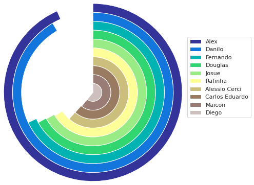

```python
labels = list(pen_df.Player_Name[:10])
data = list(pen_df.Penalties[:10])

#number of data points
n = len(data)
#find max value for full ring
k = 10 ** int(log10(max(data)))
m = k * (1 + max(data) // k)

#radius of donut chart
r = 2
#calculate width of each ring
w = r / n

#create colors along a chosen colormap
colors = [cm.terrain(i / n) for i in range(n)]

#create figure, axis
fig, ax = plt.subplots()
ax.axis("equal")

#create rings of donut chart
for i in range(n):
    #hide labels in segments with textprops: alpha = 0 - transparent, alpha = 1 - visible
    innerring, _ = ax.pie([m - data[i], data[i]], radius = r - i * w, startangle = 90, labels = ["", labels[i]], labeldistance = 1 - 1 / (1.5 * (n - i)), textprops = {"alpha": 0}, colors = ["white", colors[i]])
    plt.setp(innerring, width = w, edgecolor = "white")

plt.legend(bbox_to_anchor=(1.05, 1), loc='upper left', borderaxespad=0)
plt.show();
```

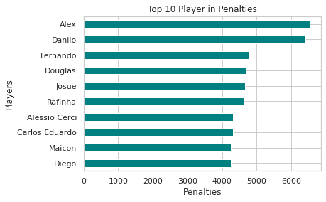

```python
pen_df[:10].plot.barh(x='Player_Name', y='Penalties', color = '#008080', legend=None).invert_yaxis()
plt.xlabel('Penalties')
plt.ylabel('Players')
plt.title('Top 10 Player in Penalties');
```

## Limitation

- Some columns by definition have a great impact on the analysis but due to wrong scraping outcome they are dropped.
- Player XY coordinates are vague. Plotting a football field map with correspond player positions would be diverting.